# Final Project

Rakel María Brynjólfsdóttir og Ævar Ingi Jóhannesson

March 23, 2018

```r
library(plyr); library(dplyr); library(lubridate)
library(ggplot2)
library(grid)
library(gridExtra)
library(glmnet)
library(e1071)
library(randomForest)
library(knitr)
library(gbm)
```

We start by loading the data which has already been cleaned. The particulars of the data preproccesing can be seen in the appendix.

```r
data = read.csv("MyData.csv")
```

The data is now as follows:

| Variable | type | Description | levels |
| --- | --- | --- | --- |
| kdagur | numerical | days since last bought |  |
| nuvirdi | numerical | log of current price |  |
| teg_eign | factor | type of property | Einbýlishús, Fjölbýlishús, Íbúðareign, Íbúðarhús, Raðhús |
| svfn | factor | town id | Grb, Hfj, Kop, Mos, Rvk, Sel |
| aldur | numerical | age of house |  |
| fjmib | factor | nr of apartments | 1,2,3,4 |
| lyfta | factor | elevator or not | 0,1 |
| ummal | numerical | circumference of property |  |
| ibm2 | numerical | area of property |  |
| ntm2 | numerical | netto area of property |  |
| fjhaed | factor | number of floors | 1,2,3,4 |
| fjbkar | factor | number of bathtubs | 0,1,2 (2 or more) |
| fjsturt | factor | number of showers | 0,1,2 (2 or more) |
| fjklos | factor | number of toilets | 0,1,2 (2 or more) |
| fjeld | factor | number of kitchens | 0,1,2 (2 or more) |
| fjherb | factor | number of rooms | 0,1,2,3,4,5,6 (6 or more) |
| fjstof | factor | number of livingrooms | 0,1,2 (2 or more) |
| stig10 | numerical | construction stage |  |
| bilskurm2 | numerical | area of garage |  |
| svalm2 | numerical | area of balcony |  |
| geymm2 | numerical | area of storage space |  |
| matssvaedi | factor | location | 60 levels |
| undirmatssvaedi | factor | sub-location | 62 levels |
| ibteg | factor | type of property | 1(single-family), 2(aparment building) |

### Descriptive plots of the data

We start by looking at the density of the $\texttt{nuvirdi}$ variable.

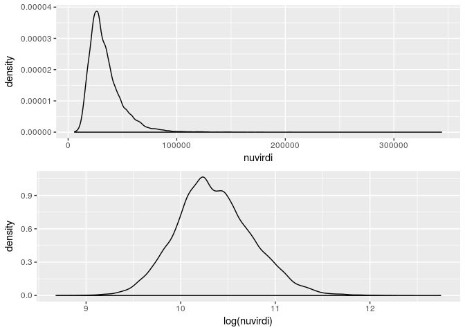

```r
density1 <- ggplot(data,aes(nuvirdi))+
  geom_density()

density2 <- ggplot(data,aes(log(nuvirdi)))+
  geom_density()

grid.arrange(density1,density2,nrow=2)
```

It’s evident that when we plot $\texttt{nuvirdi}$ on a log scale it looks a lot more like the normal distribution, so we’re going to log transform the response.

```r
data$nuvirdi = log(data$nuvirdi)
```

Let’s plot $\texttt{nuvirdi}$ against some variables to see if there are any relationships.

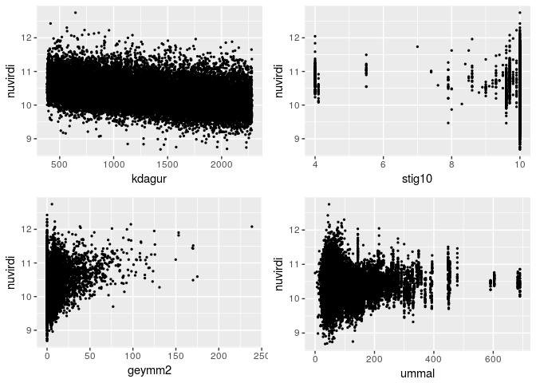

```r
p1 <- ggplot(data, aes(x=kdagur,y=nuvirdi)) +
          geom_point(size=0.5)+
          theme_grey()

p2 <- ggplot(data, aes(x=stig10,y=nuvirdi)) +
          geom_point(size=0.5) +
          theme_grey()

p3 <- ggplot(data, aes(x=geymm2,y=nuvirdi)) +
          geom_point(size=0.5) +
          theme_grey()

p4 <- ggplot(data, aes(x=ummal,y=nuvirdi)) +
          geom_point(size=0.5) +
          theme_grey()

p5 <- ggplot(data, aes(x=aldur,y=nuvirdi)) +
          geom_point(size=0.5) +
          theme_grey()

p6 <- ggplot(data, aes(x=bilskurm2,y=nuvirdi)) +
          geom_point(size=0.5) +
          theme_grey()

p7 <- ggplot(data, aes(x=svalm2,y=nuvirdi)) +
          geom_point(size=0.5) +
          theme_grey()

p8 <- ggplot(data, aes(x=ibm2,y=nuvirdi)) +
          geom_point(size=0.5) +
          theme_grey()

grid.arrange(p1,p2,p3,p4,nrow = 2)
```

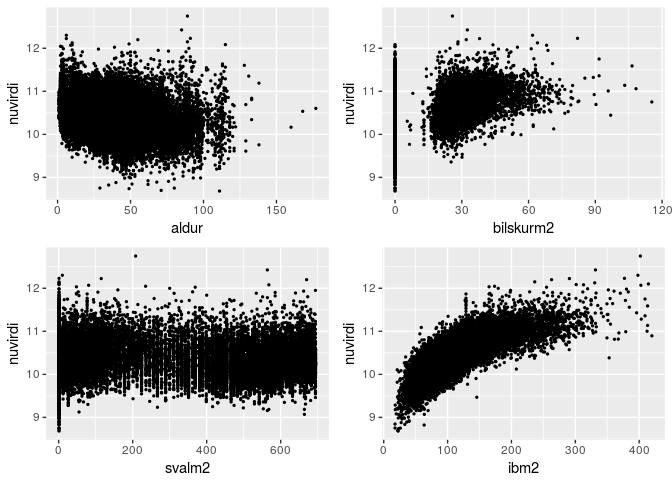

```r
grid.arrange(p5,p6,p7,p8,nrow = 2)
```

It looks like $\texttt{geymm2}$, $\texttt{bilskurm2}$ and $\texttt{ibm2}$ might have a more linear relatioship with nuvirdi on a log scale.

```r
B = data$bilskurm2
ind1 = which(B == 0)
B[-ind1] = log(B[-ind1])
I = log(data$ibm2)
G = data$geymm2
ind3 = which(G == 0)
G[-ind3] = log(G[-ind3])
```

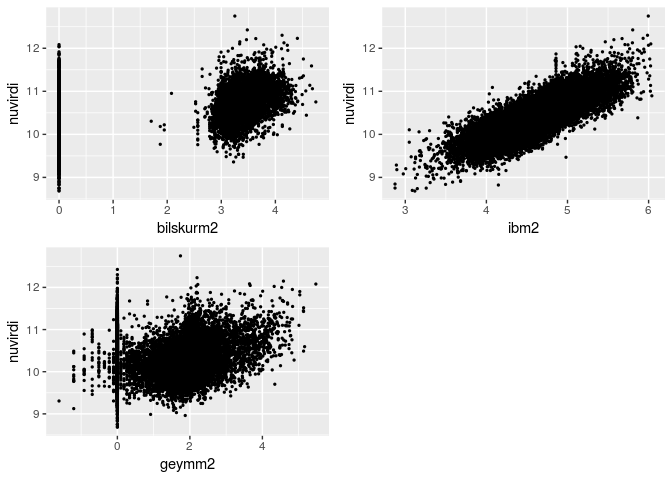

```r
p1 <- ggplot(data, aes(x=B,y=nuvirdi)) +
          geom_point(size=0.5)+
          theme_grey() + labs(x="bilskurm2")

p2 <- ggplot(data, aes(x=I,y=nuvirdi)) +
          geom_point(size=0.5) +
          theme_grey() + labs(x="ibm2")

p3 <- ggplot(data, aes(x=G,y=nuvirdi)) +
          geom_point(size=0.5) +
          theme_grey() + labs(x="geymm2")

grid.arrange(p1,p2,p3,nrow = 2)
```

A log transformation is not suitable for the $\texttt{bilskurm2}$ variable, but it definitely is for $\texttt{ibm2}$ and $\texttt{geymm2}$, although we will have to shift the values so that they are positive.

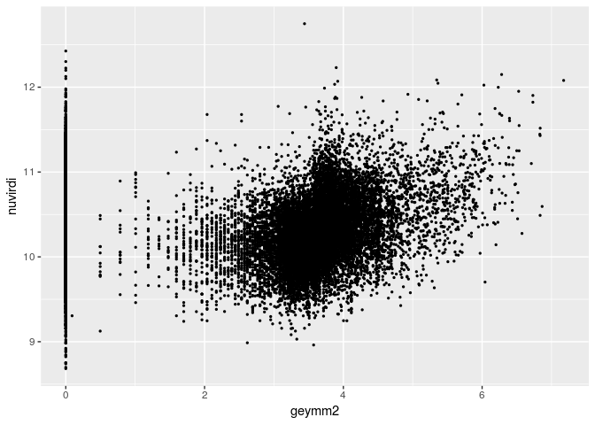

```r
data$ibm2 = log(data$ibm)
G[-ind3] = G[-ind3] + 1.7
data$geymm2 = G
ggplot(data, aes(x=geymm2,y=nuvirdi)) +
          geom_point(size=0.5) +
          theme_grey()
```

Now we’ll make some box plots of the factor variables.

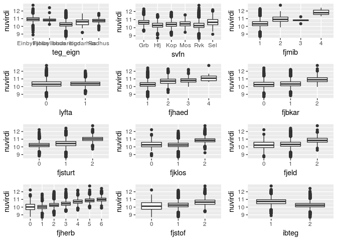

```r
f1 <- ggplot(data,aes(x=teg_eign,y=nuvirdi))+
          geom_boxplot()

f2 <- ggplot(data,aes(x=svfn,y=nuvirdi))+
          geom_boxplot()

f3 <- ggplot(data,aes(x=fjmib,y=nuvirdi))+
          geom_boxplot()

f4 <- ggplot(data,aes(x=lyfta,y=nuvirdi))+
          geom_boxplot()

f5 <- ggplot(data, aes(x=fjhaed,y=nuvirdi)) +
          geom_boxplot()

f6 <- ggplot(data,aes(x=fjbkar,y=nuvirdi))+
          geom_boxplot()

f7 <- ggplot(data,aes(x=fjsturt,y=nuvirdi))+
          geom_boxplot()

f8 <- ggplot(data,aes(x=fjklos,y=nuvirdi))+
          geom_boxplot()

f9 <- ggplot(data,aes(x=fjeld,y=nuvirdi))+
          geom_boxplot()

f10 <- ggplot(data,aes(x=fjherb,y=nuvirdi))+
          geom_boxplot()

f11 <- ggplot(data, aes(x=fjstof,y=nuvirdi)) +
          geom_boxplot()

f12 <- ggplot(data, aes(x=ibteg,y=nuvirdi)) +
          geom_boxplot()

grid.arrange(f1,f2,f3,
             f4,f5,
             f6,f7,
             f8,f9,f10,f11,f12,ncol=3)
```

Most of the factor variables seem to have a relationship with $\texttt{nuvirdi}$, especially $\texttt{fjmib}$, $\texttt{fjhaed}$ and $\texttt{fjherb}$.

Finally, we’ll check the correlation between the numerical variables.

```r
X = with(data,cbind(kdagur,aldur,ummal,ibm2,stig10,bilskurm2,svalm2,geymm2))
cor(X)
```

```
##                 kdagur        aldur       ummal        ibm2       stig10
## kdagur     1.000000000  0.040465121 -0.01982544 -0.02541308  0.100851363
## aldur      0.040465121  1.000000000 -0.48287217 -0.23820679  0.126304657
## ummal     -0.019825441 -0.482872166  1.00000000 -0.02976964 -0.081362285
## ibm2      -0.025413084 -0.238206790 -0.02976964  1.00000000 -0.018322023
## stig10     0.100851363  0.126304657 -0.08136229 -0.01832202  1.000000000
## bilskurm2 -0.006861080  0.008303151 -0.22584017  0.57326707  0.012716589
## svalm2     0.004393164 -0.172829499  0.16147506 -0.03153840 -0.007956578
## geymm2    -0.015298009 -0.171429733  0.30142807 -0.15888779 -0.064797805
##              bilskurm2       svalm2      geymm2
## kdagur    -0.006861080  0.004393164 -0.01529801
## aldur      0.008303151 -0.172829499 -0.17142973
## ummal     -0.225840174  0.161475058  0.30142807
## ibm2       0.573267072 -0.031538399 -0.15888779
## stig10     0.012716589 -0.007956578 -0.06479780
## bilskurm2  1.000000000 -0.118989076 -0.27504912
## svalm2    -0.118989076  1.000000000  0.16159258
## geymm2    -0.275049122  0.161592583  1.00000000
```

None of the variables are highly correlated.

### Modeling the data

When exploring the data we realised that the $\texttt{svfn}$ variable and the two $\texttt{matssvaedi}$ variables are linearly dependent since they are describing the same thing. For the regression part we decided to use the $\texttt{matssvaedi}$ variables and for the classification we are going to use the $\texttt{svfn}$ variable. We will evaluate both data sets, transformed (log-scaled) and normal.

```r
dat = data
datN = dataOriginal
svfn = dat$svfn
svfnN = datN$svfn
dat$svfn = NULL
datN$svfn = NULL
```

Now we’ll split the data into a training set with 80% of the data and a test set.

```r
set.seed(5040)
n = dim(dat)[1]
train = sample(n,floor(n*0.8))
dat.train = dat[train,]
dat.test = dat[-train,]
datN.train = datN[train,]
datN.test = datN[-train,]
```

## Linear Regression

To start we are using linear regression to predict (the log of) $\texttt{nuvirdi}$

```r
fit.lm = lm(nuvirdi~.,dat.train)
summary(fit.lm)
```

```
##
## Call:
## lm(formula = nuvirdi ~ ., data = dat.train)
##
## Residuals:
##      Min       1Q   Median       3Q      Max
## -1.17711 -0.06998 -0.00153  0.06947  0.86291
##
## Coefficients:
##                          Estimate   Std. Error  t value
## (Intercept)           8.171727603  0.032375926  252.401
## kdagur               -0.000271626  0.000001549 -175.389
## teg_eignFjolbylishus -0.057140942  0.027232850   -2.098
## teg_eignIbudareign   -0.150920596  0.005072333  -29.754
## teg_eignibudarhus     0.005992235  0.022507660    0.266
## teg_eignRadhus       -0.059125240  0.004640708  -12.741
## aldur                -0.002141149  0.000072633  -29.479
## fjmib2                0.073799353  0.013525045    5.456
## fjmib3                0.116709500  0.063484402    1.838
## fjmib4                0.255533106  0.076792825    3.328
## lyfta1                0.019712534  0.002889579    6.822
## ummal                 0.000082900  0.000016379    5.061
## ibm2                  0.630726094  0.004833449  130.492
## fjhaed2              -0.032753428  0.003296310   -9.936
## fjhaed3              -0.059268196  0.006901713   -8.587
## fjhaed4               0.020174718  0.037987112    0.531
## fjbkar1              -0.000454070  0.002727599   -0.166
## fjbkar2               0.003818052  0.009420036    0.405
## fjsturt1              0.013790499  0.002247762    6.135
## fjsturt2              0.025077085  0.005511043    4.550
## fjklos1              -0.001153457  0.011754331   -0.098
## fjklos2               0.033709981  0.012168134    2.770
## fjeld1                0.009082983  0.011402209    0.797
## fjeld2               -0.020219888  0.014372359   -1.407
## fjherb1              -0.023935895  0.009140405   -2.619
## fjherb2               0.004980010  0.009245583    0.539
## fjherb3               0.012254353  0.009488524    1.291
## fjherb4               0.009565801  0.009981144    0.958
## fjherb5              -0.020918699  0.010865840   -1.925
## fjherb6              -0.050049492  0.011610904   -4.311
```

[output cut: 276 more lines]

```
## undirmatssvaedi64    0.000000000007633929 ***
## undirmatssvaedi65                0.002016 **
## undirmatssvaedi101               0.065134 .
## undirmatssvaedi103   0.000038250409937730 ***
## undirmatssvaedi104   < 0.0000000000000002 ***
## undirmatssvaedi105   0.000000000000042139 ***
## undirmatssvaedi106   < 0.0000000000000002 ***
## undirmatssvaedi107   0.000000282007746032 ***
## ibteg2               < 0.0000000000000002 ***
## ---
## Signif. codes:  0 '***' 0.001 '**' 0.01 '*' 0.05 '.' 0.1 ' ' 1
##
## Residual standard error: 0.123 on 22559 degrees of freedom
## Multiple R-squared:  0.9093, Adjusted R-squared:  0.9086
## F-statistic:  1449 on 156 and 22559 DF,  p-value: < 0.00000000000000022
```

All of the numerical variables are significant and most of the factors have significant levels, apart from $\texttt{fjbkar}$ and $\texttt{fjeld}$. The $R^2$-adjusted for this model is $0.9086$.

Now we’ll do the same for the non-transformed data.

```r
fitN.lm = lm(nuvirdi~.,datN.train)
summary(fitN.lm)
```

```
##
## Call:
## lm(formula = nuvirdi ~ ., data = datN.train)
##
## Residuals:
##    Min     1Q Median     3Q    Max
## -63221  -2502   -170   2242 186221
##
## Coefficients:
##                          Estimate   Std. Error  t value
## (Intercept)           39018.91832   1230.19488   31.718
## kdagur                   -8.52630      0.07489 -113.853
## teg_eignFjolbylishus  -3144.27820   1316.63857   -2.388
## teg_eignIbudareign    -6463.07348    247.06670  -26.159
## teg_eignibudarhus      -877.61211   1089.41977   -0.806
## teg_eignRadhus        -3988.40269    225.75355  -17.667
## aldur                   -73.68622      3.49930  -21.057
## fjmib2                 8116.05746    654.34483   12.403
## fjmib3                 1915.60457   3069.70999    0.624
## fjmib4                62408.16107   3718.94896   16.781
## lyfta1                  647.44178    139.23251    4.650
## ummal                     3.39772      0.79049    4.298
## ibm2                    212.82640      2.12822  100.002
## fjhaed2               -1456.67033    160.01429   -9.103
## fjhaed3               -3138.67397    336.43367   -9.329
## fjhaed4               17546.68703   1841.61910    9.528
## fjbkar1                  43.90452    131.65436    0.333
## fjbkar2                 902.92611    456.19616    1.979
## fjsturt1                285.50405    108.85879    2.623
## fjsturt2               2610.86574    270.99691    9.634
## fjklos1                -335.40308    567.91925   -0.591
## fjklos2                1392.99994    588.25980    2.368
## fjeld1                  155.58998    551.19509    0.282
## fjeld2                -2590.53566    694.77583   -3.729
## fjherb1                -249.51406    442.01730   -0.564
## fjherb2                 744.92020    442.95411    1.682
## fjherb3                 855.01868    450.51517    1.898
## fjherb4                 335.72844    473.68559    0.709
## fjherb5               -1636.30638    519.26806   -3.151
## fjherb6               -4567.90889    563.67211   -8.104
```

[output cut: 276 more lines]

```
## undirmatssvaedi64    0.000000073553242446 ***
## undirmatssvaedi65    0.000000000433292698 ***
## undirmatssvaedi101               0.228219
## undirmatssvaedi103               0.001177 **
## undirmatssvaedi104   < 0.0000000000000002 ***
## undirmatssvaedi105               0.000266 ***
## undirmatssvaedi106   0.000000000000000366 ***
## undirmatssvaedi107               0.000110 ***
## ibteg2               0.000000018555566468 ***
## ---
## Signif. codes:  0 '***' 0.001 '**' 0.01 '*' 0.05 '.' 0.1 ' ' 1
##
## Residual standard error: 5948 on 22559 degrees of freedom
## Multiple R-squared:  0.8608, Adjusted R-squared:  0.8598
## F-statistic: 893.9 on 156 and 22559 DF,  p-value: < 0.00000000000000022
```

Finally we will calculated the MSE for the two models.

```r
pred.lm = predict(fit.lm, dat.test)
RssLin = as.integer(mean((exp(dat.test$nuvirdi)-exp(pred.lm))^2))

predN.lm = predict(fitN.lm, datN.test)
RssLinN = as.integer(mean((datN.test$nuvirdi - predN.lm)^2))
```

The MSE for the first model is 29136614 and 34703492 for the second model. Therefore it’s clear that a log transformation is suitable when performing linear regression on this data.

# Diagnostics of linear regression

Here below we can see some plots for the linear regression model (log scaled).

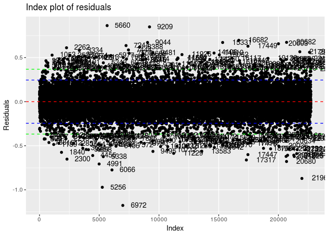

```r
diagnost = fortify(fit.lm)
diagnost$.index = 1:(dim(diagnost)[1])
res_sd = sd(diagnost$.resid)
resPlot = ggplot(diagnost, aes(x=seq(1:length(.resid)),y=.resid)) +
                geom_point()+
                geom_hline(yintercept=0, col="red", linetype="dashed")+
                geom_hline(yintercept=2*res_sd, col="blue", linetype="dashed")+
                geom_hline(yintercept=-2*res_sd, col="blue", linetype="dashed")+
                geom_hline(yintercept=3*res_sd, col="green", linetype="dashed")+
                geom_hline(yintercept=-3*res_sd, col="green", linetype="dashed")+
                xlab("Index")+ylab("Residuals")+labs(title = "Index plot of residuals")+
                geom_text(aes(label=ifelse(abs(.resid)>3*res_sd,.index,"")),
                      hjust=-.5, vjust=0.4)+
                theme_grey()
resPlot
```

Here we can see the residuals plotted against their index. The blue line is 2 times the standard deviation of the residuals and the green line is 3 times the standard deviation. We can see that there are few points that exceed the green line and they could be looked at more closely. Also we can see that there seems to be a constant variance.

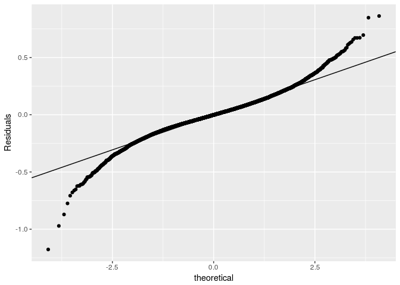

```r
QQPlot<-ggplot(diagnost, aes(sample = .resid))+
        stat_qq()+
        geom_abline(slope=res_sd)+
        ylab("Residuals")+
        theme_grey()
QQPlot
```

Here we can see the normal Q-Q plot for the model. It looks good and they seem to follow a normal distribution but the ends are quite spread out so the distribution is heavy tailed.

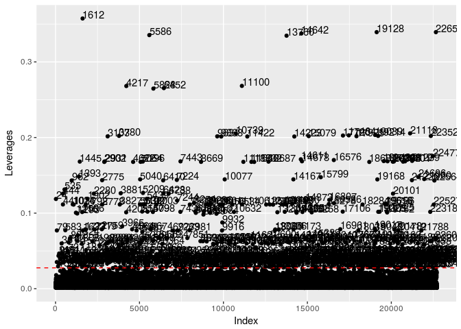

```r
LevPlot <- ggplot(diagnost, aes(x=seq(1:length(.hat)),y=.hat))+
                  geom_point()+
                  geom_hline(yintercept=4*mean(diagnost$.hat), col="red", linetype="dashed")+
                  xlab("Index")+
                  ylab("Leverages")+
                  geom_text(aes(label=ifelse(.hat > 4*mean(diagnost$.hat),.index,"")),
                            hjust=0, vjust=0)+
                  theme_grey()
LevPlot
```

Here we can see the Leverage plot. There seems to be few points that have very high leverage. These points should be looked at more closely to examine weather they are outliers or not.

## Lasso Regression

Now we use Lasso regression to see if it improves the linear regression.

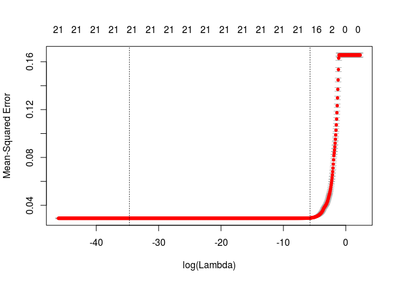

```r
set.seed(5040)
ytrain = data.matrix(dat.train[,"nuvirdi"])
Xtrain = data.matrix(dat.train[,!(colnames(dat.train) %in% c("nuvirdi"))])
Xtest = data.matrix(dat.test[,!(colnames(dat.train) %in% c("nuvirdi"))])
grid = 10^seq(1, -20, length=1000)
fit.lasso = cv.glmnet(Xtrain,ytrain,alpha=1, lambda=grid, thresh=1e-12)
plot(fit.lasso)
```

From the plot above it seems that the best lambda has no zero predictors.

```r
best.lambda = fit.lasso$lambda.min
pred.lasso = predict(fit.lasso,Xtest,s=best.lambda)
RssLasso = as.integer(mean((exp(dat.test$nuvirdi)-exp(pred.lasso))^2))
```

The best $\lambda$ is $8.708\times 10^{-16}$ which is very small so there is not much penalty on the size of coefficients. The corresponding MSE is 54941789 which is much higher than we got for linear regression.

```r
best.model = glmnet(Xtrain, ytrain, alpha = 1)
predict(best.model, s = fit.lasso$lambda.1se, type = "coefficients")
```

```
## 22 x 1 sparse Matrix of class "dgCMatrix"
##                             1
## (Intercept)      7.4950650953
## kdagur          -0.0002600357
## teg_eign        -0.0102267953
## aldur           -0.0003563501
## fjmib            0.0494894623
## lyfta            0.0518312263
## ummal            0.0001616056
## ibm2             0.7303618392
## fjhaed          -0.0300738727
## fjbkar          -0.0250922487
## fjsturt          0.0448068815
## fjklos           0.0512507352
## fjeld            .
## fjherb          -0.0075321153
## fjstof           0.0000540531
## stig10          -0.0187914667
## bilskurm2        0.0032994821
## svalm2           .
## geymm2           0.0150729322
## matssvaedi      -0.0029568448
## undirmatssvaedi  0.0015344389
## ibteg           -0.0619180072
```

The first three predictors that tend to zero are $\texttt{fjeld}$, $\texttt{fjstof}$ and $\texttt{svalm2}$.

Now we fit a Lasso model on the normal data.

```r
set.seed(5040)
ytrainN = data.matrix(datN.train[,"nuvirdi"])
XtrainN = data.matrix(datN.train[,!(colnames(dat.train) %in% c("nuvirdi"))])
XtestN = data.matrix(datN.test[,!(colnames(dat.train) %in% c("nuvirdi"))])
fitN.lasso = cv.glmnet(XtrainN,ytrainN,alpha=1, lambda=grid, thresh=1e-12)

bestN.lambda = fitN.lasso$lambda.min
predN.lasso = predict(fitN.lasso,XtestN,s=bestN.lambda)
RssLassoN = as.integer(mean((datN.test$nuvirdi - predN.lasso)^2))
```

Here we get $\lambda =$ 9.5275005 and the MSE for this model is 56216153 so a little higher than for the log-scaled data.

## Boosting

Here we perform our final method in regression to predict $\texttt{nuvirdi}$. We start by checking which values of lambda gives us the best error. We do this simultaneously for the tranformed and untransformed data.

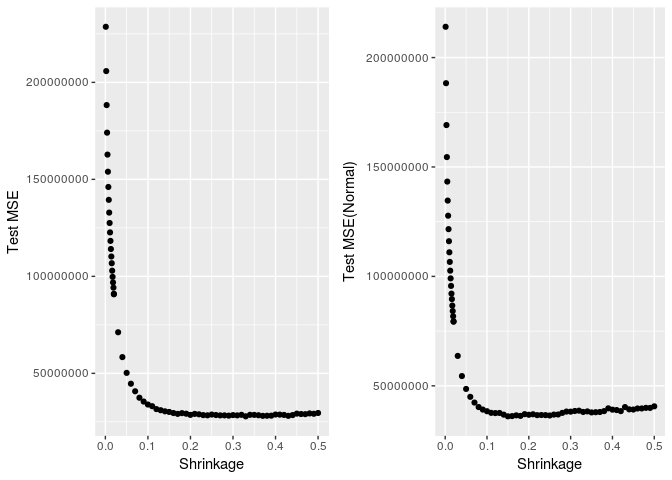

```r
set.seed(5040)
lambd <-  seq(0.001, 0.02, by=0.001)
lambd <- c(lambd, seq(0.02, 0.5, by=0.01))
m <- length(lambd)
testErr <- rep(NA, m)
testErrN <- rep(NA, m)
for (i in 1:m) {
    boostCol = gbm(nuvirdi ~ ., data = dat.train,
                    distribution = "gaussian",
                    n.trees = 200,
                    shrinkage = lambd[i])
    testPred = predict(boostCol, dat.test, n.trees = 200)
    testErr[i] = mean((exp(dat.test$nuvirdi) - exp(testPred))^2)
    boostColN = gbm(nuvirdi ~ ., data = datN.train,
                    distribution = "gaussian",
                    n.trees = 200,
                    shrinkage = lambd[i])
    testPredN = predict(boostColN, datN.test, n.trees = 200)
    testErrN[i] = mean((datN.test$nuvirdi - testPredN)^2)
}

bestLam = lambd[which.min(testErr)]
bestLamN = lambd[which.min(testErrN)]

boostPlot =ggplot(data.frame(x=lambd, y=testErr), aes(x=x, y=y)) +
            xlab("Shrinkage") +
            ylab("Test MSE") +
            geom_point()

boostPlot2 = ggplot(data.frame(x=lambd, y=testErrN), aes(x=x, y=y)) +
              xlab("Shrinkage") +
              ylab("Test MSE(Normal)") +
              geom_point()

grid.arrange(boostPlot,
             boostPlot2,ncol=2)
```

From the plot above we can see how the MSE decreases as a function of $\lambda$ and then increases slightly again. We get that the lowest $\lambda$ for the transformed data it’s $\lambda=0.33$. For the normal data it’s $\lambda=0.15$. Now we fit a boosting model using 1000 trees with these $\lambda$.

```r
set.seed(5040)
boost.fit <- gbm(nuvirdi ~ ., data = dat.train, distribution = "gaussian",
                 n.trees = 1000, shrinkage =bestLam )
boost.pred <- predict(boost.fit, dat.test, n.trees = 1000)
RssBoost = as.integer(mean((exp(dat.test$nuvirdi) - exp(boost.pred))^2))
```

The MSE for the Boosting model is 27786447 which is the lowest we’ve seen so far.

Now we repeat this on the untransformed data.

```r
boostN.fit <- gbm(nuvirdi ~ ., data = datN.train, distribution = "gaussian",
                  n.trees = 1000, shrinkage =bestLamN )
boostN.pred <- predict(boostN.fit, datN.test, n.trees = 1000)
RssBoostN = as.integer(mean((datN.test$nuvirdi - boostN.pred)^2))
```

Now we get en MSe of 36111501 which is a lot higher than for the transformed data.

```r
linear_summary <- c(RssLin,RssLinN)
lasso_summary <- c(RssLasso,RssLassoN)
boost_summary <- c(RssBoost,RssBoostN)

table <- rbind(linear_summary,lasso_summary,boost_summary)
rownames(table) <- c("Linear","Lasso", "Boosting")
colnames(table) <- c("MSE (Log)","MSE Normal")
kable(round(table,6),caption = "Summary of MSE from the methods")
```

Summary of MSE from the methods

|  | MSE (Log) | MSE Normal |
| --- | --- | --- |
| Linear | 29136614 | 34703492 |
| Lasso | 54941789 | 56216153 |
| Boosting | 27786447 | 36111501 |

From the table above we can see that Boosting and linear regression on the transformed data are doing the best job in predicting $\texttt{nuvirdi}$

### Classification

Here we are going to predict in which town ($\texttt{svfn}$) the properties belong are. We start by taking only properties from Reykjavik, Kopavogi and Hafnarfirði.

So the classes are

- Rvk
- Kop
- Hfj

Now we add the $\texttt{svfn}$ variable back to the data frame and remove the $\texttt{matssvaedi}$ variables.

```r
dat = data.frame(dat,svfn)
mats = dat$matssvaedi
undir = dat$undirmatssvaedi
dat$matssvaedi = NULL
dat$undirmatssvaedi = NULL

area = levels(data$svfn)[c(2,3,5)]
dat = dat[which(data$svfn %in% area),]
dat$svfn = droplevels(dat$svfn)
```

```r
datN = data.frame(datN,svfn)
mats = datN$matssvaedi
undir = datN$undirmatssvaedi
datN$matssvaedi = NULL
datN$undirmatssvaedi = NULL

datN = datN[which(data$svfn %in% area),]
datN$svfn = droplevels(datN$svfn)
```

```r
set.seed(5040)
n = dim(dat)[1]
p = dim(dat)[2]
train = sample(n,floor(n*0.8))

dat.train = dat[train,]
dat.test = dat[-train,]
datN.train=datN[train,]
datN.test = datN[-train,]

n2 = dim(dat.train)[1]
val = sample(n2,floor(n2*0.8))
dat.val = dat.train[-val,]
dat.train = dat.train[val,]
datN.val = datN.train[-val,]
datN.train = datN.train[val,]
```

We also split to a train set, test set and a validation set to use in cross validation for SVM.

```r
table(dat$svfn)
```

```
##
##   Hfj   Kop   Rvk
##  3883  4859 16325
```

We can see that most of the properties are in Reykjavik.